# Final Paper

STOR 320.02 Group 12

May 01, 2024

# INTRODUCTION

One of the greatest challenges to modern civilization is climate change. Climate change refers to changes in the environment spurred on by the release of carbon and other greenhouse gasses into the atmosphere. These greenhouse gasses have a cascading effect, with a distinct possibility of reaching a critical point where climate change causes more carbon to be released. Carbon traps heat in the atmosphere, which warms the planet and melts the polar caps, then releasing more carbon into the atmosphere, which builds towards further environmental change. To avoid this critical scenario, we must limit carbon output.

Towards this end, our analysis centers around a significant source of carbon being released into the atmosphere: Energy production. During our initial data analysis we looked into the relationship between foreign funding for clean energy projects and a subsequent increase in renewable energy usage. It would be easy to assume that foreign funding specifically for clean energy production would result in an increase in clean energy production; however, this was far from the case, as our initial testing defied our assumptions and made this data set stand out as worth further investigation. This mystery, and our concern for the environment, spurred us to develop two questions related to reliance on fossil fuels and a country’s usage of renewable energy. We found these questions would create an solid measurement to assess their progress towards becoming carbon neutral.

The first question Group 12 posed regarding our energy data is: Can GDP Per Capita serve as a reliable predictor of a country’s reliance on fossil fuels, and furthermore, do these predictions exhibit regional variations? This question delves into the economic determinants of energy consumption as well as examining how diverse socio-economic contexts may influence energy usage patterns. Our investigation has important implications for policymakers, businesses, and environmental advocates. Through examining the relationship between GDP Per Capita and reliance on fossil fuels, our goal is to provide insights that can assist decisions regarding energy policy and help shape sustainability initiatives. Identifying regional differences in these patterns could offer insights geared towards specific geographical contexts and help form collaborative efforts toward a greener, more equitable future.

The second question Group 12 explored is: Which combination of the variables, percentage of population with access to electricity, energy consumption in kilowatt hours per person, region, population density, and foreign aid for clean energy projects create the best model for predicting a country’s percentage of total energy that comes from renewable sources of energy? As the world attempts to transition towards renewable energy sources, identifying the key determinants of this shift could be very important for policymakers and environmental advocates. By analyzing various socio-economic, environmental, and policy-related variables, we aim to construct a predictive model that can explain current trends and help create a plan for future environmental initiatives. For governments, an understanding of key drivers of renewable energy adoption can inform the design of effective energy policies. From a global perspective, examining the factors behind renewable energy adoption contributes to the movement against climate change and advances sustainable development goals.

# DATA

Our analysis hinges upon a dataset collected by Our World in Data, pertaining to Sustainable Development Goal 7 — a commitment to ensuring access to affordable, reliable, sustainable, and modern energy for all. This dataset is a global compilation of energy-related statistics that illuminate the current state and historical trends of energy accessibility, production, and consumption. It offers a comprehensive view of how these energy metrics interact with various socio-economic indicators, including GDP growth, GDP per capita, and population density.

Our original dataset contains 3649 observations, and each observation contains the data for a specific country for a specific year ranging from 2000 to 2020. The following table is a representation of the variables we found to be most significant to our dataset using a single country.

| Year | Country | Region | Foreign Aid for Clean Energy Projects (In USD) | GDP Per Capita | CO2 Emissions Per Capita | More Energy From Renewables | Total Energy From Renewables (%) | Energy Consumption (kWh/person) | Access to electricity (% of population) |
| --- | --- | --- | --- | --- | --- | --- | --- | --- | --- |
| 2000 | Algeria | Africa | 0 | 1765.027 | 2.619 | 0 | 0.43 | 9746.524 | 98.973 |
| 2001 | Algeria | Africa | 810000 | 1740.607 | 2.538 | 0 | 0.43 | 9961.640 | 98.967 |
| 2002 | Algeria | Africa | 310000 | 1781.829 | 2.623 | 0 | 0.51 | 10180.350 | 98.953 |
| 2003 | Algeria | Africa | 90000 | 2103.381 | 2.770 | 0 | 0.47 | 10510.461 | 98.934 |
| 2004 | Algeria | Africa | 140000 | 2610.185 | 2.773 | 0 | 0.44 | 10759.022 | 98.912 |
| 2005 | Algeria | Africa | 160000 | 3113.095 | 2.877 | 0 | 0.58 | 11113.723 | 98.890 |
| 2006 | Algeria | Africa | 0 | 3478.710 | 3.009 | 0 | 0.41 | 11341.980 | 98.869 |
| 2007 | Algeria | Africa | 0 | 3950.513 | 3.049 | 0 | 0.41 | 11759.701 | 98.853 |
| 2008 | Algeria | Africa | 0 | 4923.632 | 3.145 | 0 | 0.30 | 12252.297 | 99.300 |
| 2009 | Algeria | Africa | 2190000 | 3883.271 | 3.217 | 0 | 0.31 | 12753.120 | 98.845 |
| 2010 | Algeria | Africa | 400000 | 4480.786 | 3.215 | 0 | 0.26 | 12243.156 | 98.859 |
| 2011 | Algeria | Africa | 0 | 5455.679 | 3.337 | 0 | 0.18 | 12710.541 | 98.888 |
| 2012 | Algeria | Africa | 940000 | 5592.220 | 3.657 | 0 | 0.18 | 13624.909 | 98.765 |
| 2013 | Algeria | Africa | 940000 | 5499.587 | 3.695 | 0 | 0.13 | 14130.735 | 99.002 |
| 2014 | Algeria | Africa | 940000 | 5493.057 | 3.850 | 0 | 0.07 | 15108.635 | 99.087 |
| 2015 | Algeria | Africa | 890000 | 4177.890 | 3.992 | 0 | 0.06 | 15616.311 | 99.187 |
| 2016 | Algeria | Africa | 160000 | 3946.452 | 3.879 | 0 | 0.08 | 15295.143 | 99.350 |
| 2017 | Algeria | Africa | 10000 | 4109.698 | 3.887 | 0 | 0.14 | 15164.000 | 99.635 |
| 2018 | Algeria | Africa | 50000 | 4142.019 | 3.986 | 0 | 0.19 | 15971.084 | 99.698 |
| 2019 | Algeria | Africa | 60000 | 3989.668 | 4.047 | 0 | 0.16 | 16259.053 | 99.500 |
| 2020 | Algeria | Africa | 0 | 3306.858 | 4.901 | 0 | 0.17 | 14933.807 | 99.804 |

Our dataset originally included 21 different variables. We excluded three variables that we found had no bearing on our analysis, then introduced four new variables, concluding with 22 total variables. Two were brought from outside data: population, and region. Then we created the binary variable *More Energy From Renewables*, which returns 1 for countries that use more renewable energy sources than nonrenewable, and 0 for countries that do not. Then we created one variable using population: *CO2 Emission Per Capita*, this was initially measured in kilotons, then we adjusted it to tons to aid our analysis. We made sure to clean the data by reformatting values into proper data types and removing commas and other demarcations that affected the usability of the data. We also excluded suspicious or unreliable variables, the most prominent example of that being the population density variable, which seemed suspicious due to it remaining stagnant across the years and only changing by country. To fix this, we recreated the population density variable using the land area variable and the total population variable that we added to our data.

We obtained additional data pertaining to the populations of the countries in our dataset from a collated population census created by the UN Department of Economic and Social Affairs, and we obtained data pertaining to regions by web scraping and cleaning a Wikipedia table that listed countries and their continental regions.

The binary variable *More Energy From Renewables* is of particular interest to our analysis of the two questions, as the first question primarily addresses countries that use more fossil fuels than renewables. We created the following figure to depict how the division between renewable and nonrenewable use changes over time:

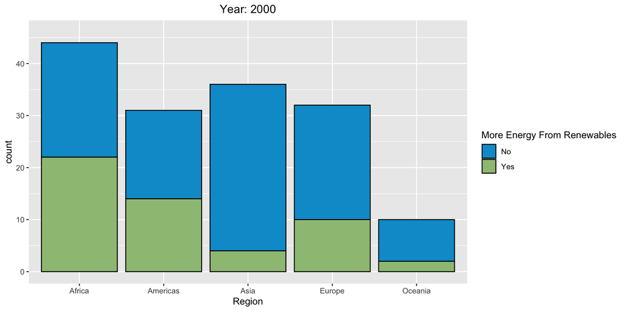

# RESULTS

In order to answer our first question we first focused on using *GDP Per Capita* to predict the binary variable, *More Energy From Renewables*, using a cross validated decision trees model. The data was cross validated with 25 folds and the model predicted the binary variable *More Energy From Renewables* using *GDP Per Capita* and controlling for *Year* and *Region*. After creating our model we plotted a decision tree created by one of our 25 folds, showing each node where the model splits the data based on one of our predictor variables.

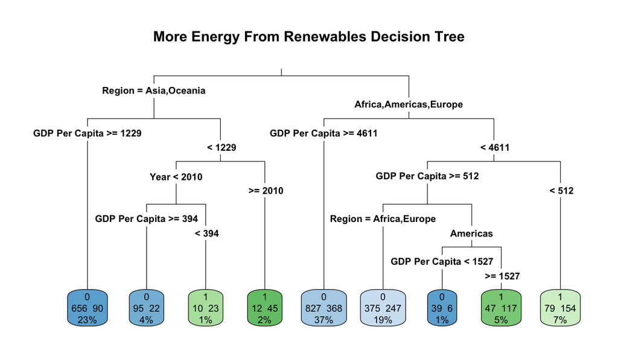

We then aggregated the final predictions from our model into a Confusion Matrix to show the predictive power of the model.

**Confusion Matrix**

|  | 0 | 1 |
| --- | --- | --- |
| 0 | 1888 | 927 |
| 1 | 349 | 182 |

After the construction of our model our Group found that one of the major limitations of the model stems from the original data source. The data was skewed in regards to whether countries use more renewable energy as close to 70% of the countries in our data set used more fossil fuels than renewable sources of energy. This is to be expected as renewable energy sources are more expensive and more prone to volatility, however it limits the number of cases available to the model. Thus our model has a strong specificity of 0.67 but a much weaker sensitivity of 0.34. Although our model has an overall accuracy of 0.62, the weak sensitivity somewhat limits the models predictive capabilities and practical application.

In order to look at another facet of our first question, we explored the relationship between *CO2 Emissions Per Capita* and *GDP Per Capita*. We first plotted a graph with *GDP Per Capita* on the x-axis and *CO2 Per Capita* on the y-axis and used the function geom_smooth with the method lm to show *GDP Per Capita* as a predictor of *CO2 Emissions Per Capita*. The graph shows a relatively strong positive correlation between *GDP Per Capita* and *CO2 Emissions Per Capita*.

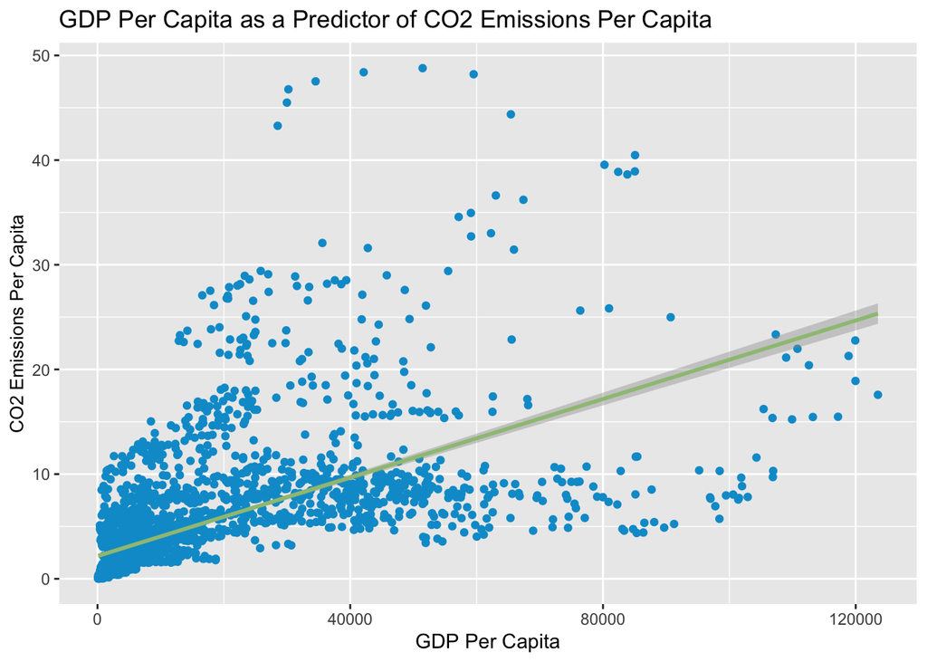

Our group wanted to explore whether this strong relationship existed for each region and whether the relationship was stronger for some regions compared to others. Our first step was creating similar plots to show the correlation between *GDP Per Capita* and *CO2 Emissions Per Capita* for each of our 5 regions. There is a positive correlation for each region with Africa and Oceania exhibiting the strongest correlations. This plot is meant to highlight that region dependent effects are not biasing our prior plot and that this positive relationship between *GDP Per Capita* and *CO2 Emissions Per Capita* exists for each region. We standardized the y limits to 30 to better show comparisons between regions but gave Asia a y limit of 50 due to its much higher values for *CO2 Emissions Per Capita*.

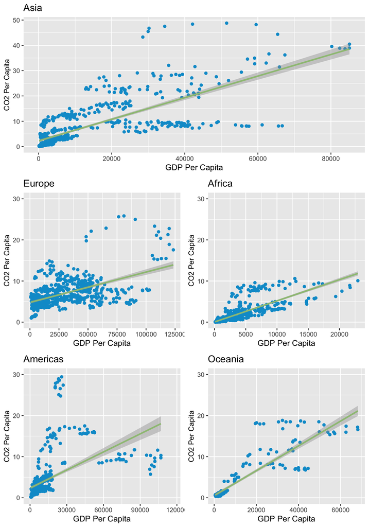

In order to investigate our second question, we used a stepwise regression to test which combination of the variables: *Access to electricity (% of population)*, *Energy Consumption (kWh/person)*, *Region*, *Population Density*, *Foreign Aid for Clean Energy Projects (In USD)*, best predicted *Total Energy From Renewables (%)*. The stepwise regression found the best model used all of these variables and each had a statistically significant p-value less than 0.05. The model had an AIC of 8305.73 the lowest of each tested model. We then calculated the MAE and r-squared values for each linear model tested by the stepwise regression to ensure it had found the best model. The models tested were:

- Model0: *Total Energy From Renewables (%) = 1*
- Model1: *Total Energy From Renewables (%) = Access to electricity (% of population)*
- Model2: *Total Energy From Renewables (%) = Access to electricity (% of population) + Energy Consumption (kWh/person)*
- Model3: *Total Energy From Renewables (%) = Access to electricity (% of population) + Energy Consumption (kWh/person) + Region*
- Model4: *Total Energy From Renewables (%) = Access to electricity (% of population) + Energy Consumption (kWh/person) + Region + Population Density*
- Model5: *Total Energy From Renewables (%) = Access to electricity (% of population) + Energy Consumption (kWh/person) + Region + Population Density + Foreign Aid for Clean Energy Projects (In USD)*

Our calculations confirmed that Model5 was the best model as it had the lowest MAE of 14.405, however it had a slightly lower adjusted r-squared of 0.6136 than Model4 which had an adjusted r-squared of 0.614. This difference is rather negligible but it provides evidence that the addition of the *Foreign Aid for Clean Energy Projects* variable has little effect on the predictive power of the model. This is an interesting finding and could signal that changes need to be made to the current system of funding clean energy initiatives.

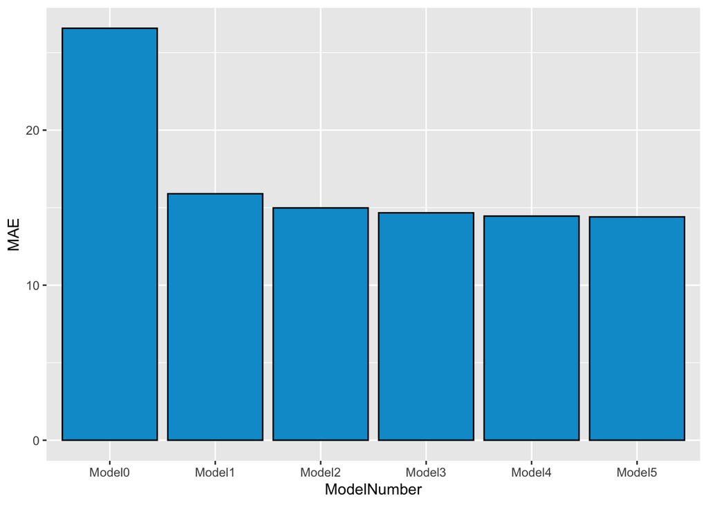

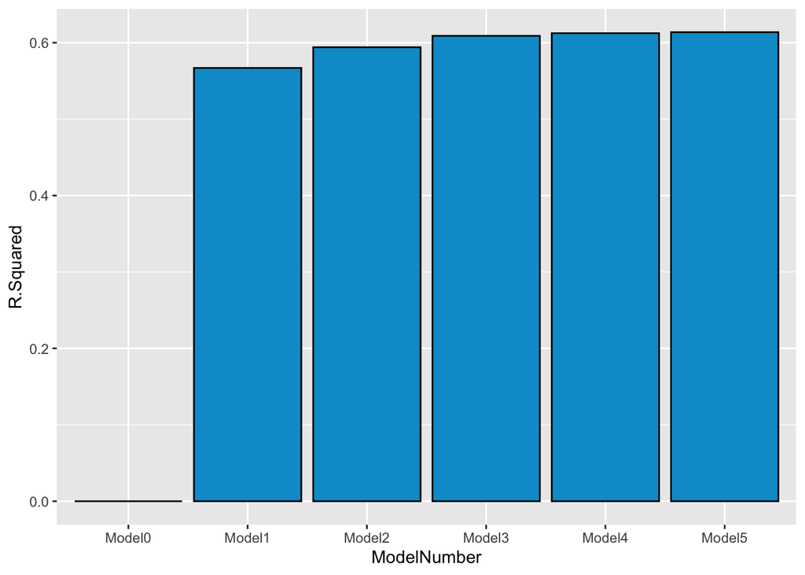

We then wanted to see if these variables had similar predictive power in different regions. We removed the region indicator from our model, for obvious reasons, and ran a stepwise regression using the other variables on subsets of our data for each region. This produced interesting findings as the only region who’s best model included the Foreign Aid variable was Africa. In this regression the variable had a even more significant p-value and larger slope. We again calculated the MAE and r-squared for each linear model tested by the regression (we did not test Model4 on the European subset data as no countries had received Foreign Aid).

- Model0: *Total Energy From Renewables (%) = 1*
- Model1: *Total Energy From Renewables (%) = Access to electricity (% of population)*
- Model2: *Total Energy From Renewables (%) = Access to electricity (% of population) + Energy Consumption (kWh/person)*
- Model3: *Total Energy From Renewables (%) = Access to electricity (% of population) + Energy Consumption (kWh/person) + Population Density*
- Model4: *Total Energy From Renewables (%) = Access to electricity (% of population) + Energy Consumption (kWh/person) + Population Density + Foreign Aid for Clean Energy Projects (In USD)*

The models for Africa and Oceania produced the highest r-squared values indicating that these variables are more indicative of renewable energy usage in these regions than the other three. Each region’s best model produced a lower MAE than the best model for the entire data set, except for Asia. This indicates that solutions for climate change and renewable energy implementation plans should be created taking into account region specific factors.

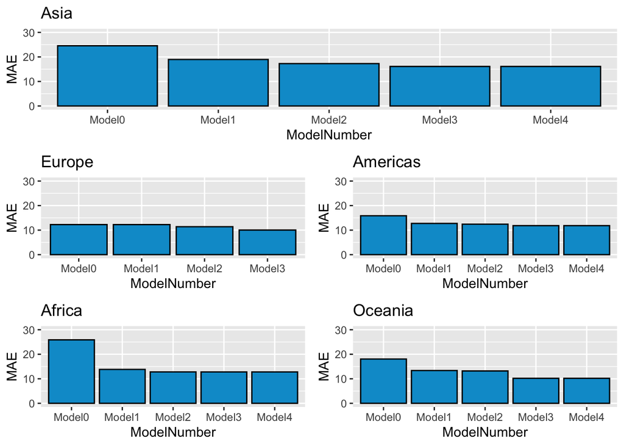

[figure not shown]

# CONCLUSION

Question two looks at a different measure of renewable energy usage, *Total Energy From Renewables (%)*. We tested which combination of the variables, *Access to electricity (% of population)*, *Energy Consumption (kWh/person)*, *Region*, *Population Density*, and *Foreign Aid for Clean Energy Projects (In USD)*, produced the strong model for predicting *Total Energy From Renewables (%)*. We found that for the entire data set a model using all of these variables had the strongest predictive power as it had the lowest MAE and the second highest adjusted r-squared, although the difference between that model and the model excluding *Foreign Aid for Clean Energy Projects (In USD)* was rather negligible. When we looked at it region by region a combination of *Access to electricity (% of population)*, *Energy Consumption (kWh/person)*, and *Population Density* produced the strongest models for all regions except Africa where *Foreign Aid for Clean Energy Projects (In USD)* was included in the best model.

The results from both of our questions can be useful for both policymakers and environmental agencies across the globe. Understanding what socio-economic, environmental, and regional factors lead to increased carbon production as well as what factors are correlated with higher usage of renewable energy gives environmental agencies and governments a starting point for enacting environmental policy and global climate initiatives. Discovering the relative insignificance of the variable *Foreign Aid for Clean Energy Projects (In USD)* compared to the other regressors used in question two highlights a need for change in our current system of foreign funding for clean energy initiatives.

While our data set was fairly useful overall, one potentially very useful variable needed to be more consistent to be used properly. The variable *Renewable Energy Production Capacity (Per Capita)* was strewn with NAs to the point where it was unusable in our analysis. Examining what factors led to a country having higher renewable energy production capacity would have produced a potentially helpful analysis for improving the world’s renewable energy usage. Our analysis would benefit from access to more detailed data about the economic status of countries, as we believe that GDP alone is not the most effective baseline to understand the carbon production within a country. We believe a prime avenue for further research would be analyzing the breakdown of where a country’s GDP comes from and uncovering which aspects of a country’s GDP are most connected to increasing CO2 per capita. We theorize that creating a categorical variable based on the most significant source of a country’s GDP, and then performing our models on that categorical variable would create interesting and valuable results. Unfortunately, we were unable to obtain a credible source for a breakdown of each country’s biggest sources of GDP, thus that was a significant limitation in our analysis. The most reliable method to obtain this data to perform this analysis would be to contact a data broker to purchase this information. This would further the goal of our first question, and potentially develop a new understanding of the causes for increased carbon emissions.